# Detecting Game Framing in the Danish Parliament

Bjørn August Skeel-Gjørling

14 apr 2018

## Import libraries

```r
#Loading packages
library(plyr)
library(dplyr)
library(readr)
library(ggplot2)
library(knitr)
library(scales)
library(zoo)
library(lubridate)
library(stargazer)
```

## Import data

In the code section, I import the dataset analysis in Python. Variables are renamed and duplicates are dropped. Furthermore, the information on the date of the debates are converted into a date format using lubridate.

```r
game_frame_data = read.csv("https://raw.githubusercontent.com/basgpol/ps239t-final-project/master/data/debate_game_frame.csv", header = TRUE)

game_frame_data = read.csv("debate_game_frame.csv", header = TRUE) %>%
  rename(game_frame_proportion = Game.frame.proportion) %>%   #renaming variable
  mutate(date = ymd_hms(game_frame_data$Time)) %>%  #converting to date format using lubridate
  select(c(4,3)) %>%  # dropping the first index variable
  distinct(date, game_frame_proportion) #dropping duplicates
```

## Preprocessing the data

In the following chunk of code, I first create a vector with the latest three parliamentary elections in Denmark. Thereafter, I create three new variables to the dataset. The three calculates the distance in days to the election in 2015, 2011 and 2007 respectively. Transcripts after the election are converted to NA.

```r
# Time to Election dates
election_dates = c(ymd_hms("2015-06-18T09:00:00"), ymd_hms("2011-09-15T09:00:00"), ymd_hms("2007-11-13T09:00:00")) # creating a list of election dates

game_frame_data_dates = game_frame_data %>%
  mutate(time_to_2015_election = election_dates[1] - game_frame_data$date) %>% # create a variable that calculates distance in days to 2015 election
  mutate(time_to_2015_election = replace(time_to_2015_election, which(time_to_2015_election<0), NA)) %>% #replace negatives (after election) to NA
  mutate(time_to_2011_election = election_dates[2] - game_frame_data$date) %>% # create a variable that calculates distance in days to 2011 election
  mutate(time_to_2011_election = replace(time_to_2011_election, which(time_to_2011_election<0), NA)) %>%  #replace negatives (after election) to NA
  mutate(time_to_2007_election = election_dates[3] - game_frame_data$date) %>% # create a variable that calculates distance in days to 2011 election
  mutate(time_to_2007_election = replace(time_to_2007_election, which(time_to_2007_election<0), NA)) #replace negatives (after election) to NA
```

I thereafter create a loop that returns a vector with number of days to next election no matter what election we are talking about. This vector is included as a new variable in the dataset.

```r
# For loop returning an vector with the days to next election
days_to_next_election_vetor = c() # create an empty vector
for (index in array(1:nrow(game_frame_data_dates))){
  days_to_next_election_vetor = c(days_to_next_election_vetor, min(c(game_frame_data_dates$time_to_2015_election[index],
        game_frame_data_dates$time_to_2011_election[index],
        game_frame_data_dates$time_to_2007_election[index]), na.rm = TRUE))
}
# Replace inf (observation since latest election in 2015) with NA
days_to_next_election_vetor[days_to_next_election_vetor == Inf] <- NA

#Adding a extra variable (days to next election) to the dataset
game_frame_final = game_frame_data_dates %>%
  mutate(days_to_election = days_to_next_election_vetor)
```

## Visualizations

### The cyclical nature of game framing

I first make a time-line of the usage of game frame words since end 2007. The large outliers make it difficult to detect a clear trend.

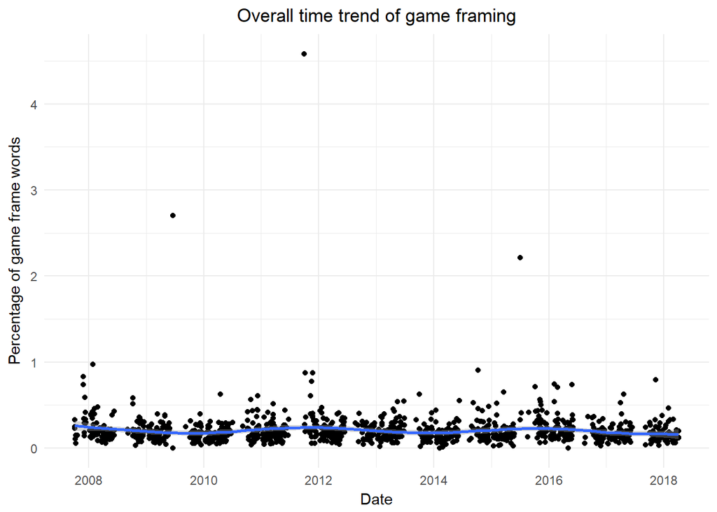

```r
### Overall time trend
overall_trend = ggplot(game_frame_final, aes(x = date, y = game_frame_proportion*100)) +
  geom_point() + # create a plot
  geom_smooth() + # create a smooth line
  theme_minimal() + # set theme
  xlab("Date")+ # set label for x-axis
  ylab("Percentage of game frame words")+ # set label for y-axis
  theme(plot.title = element_text(hjust = 0.5)) + # center plot title
  ggtitle("Overall time trend of game framing") # plot title

overall_trend
```

In the next cell, I remove three outliers of the dataset. That is the three transcripts, where the percentage of game frame words is above 2 percentage

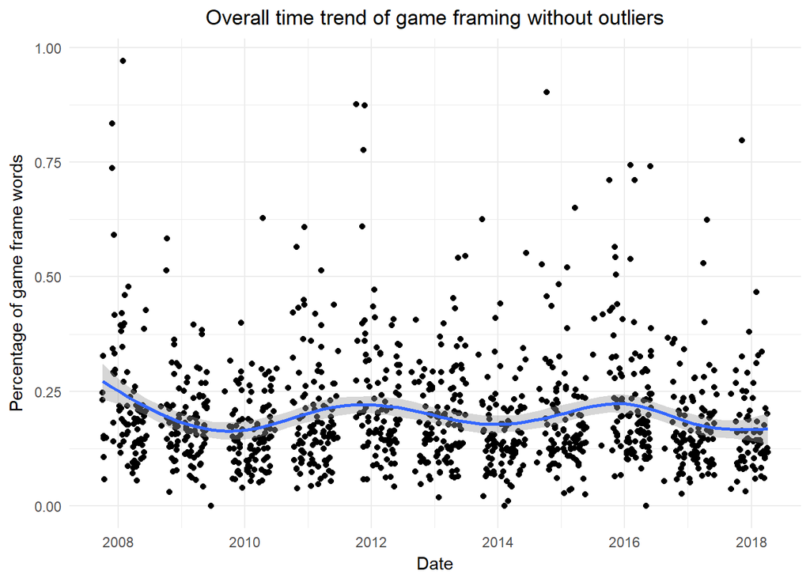

```r
game_frame_no_outliers = game_frame_final[!rowSums(game_frame_data[2] >0.02),]

overall_trend = ggplot(game_frame_no_outliers, aes(x = date, y = game_frame_proportion*100)) +
  geom_point() + # create a plot
  geom_smooth() + # create a smooth line
  theme_minimal() + # set theme
  xlab("Date")+ # set label for x-axis
  ylab("Percentage of game frame words")+ # set label for y-axis
  theme(plot.title = element_text(hjust = 0.5)) + # center plot title
  ggtitle("Overall time trend of game framing without outliers") # plot title

overall_trend
```

There is create variation in the presence of game frame words. I create a variable that calculates the rolling average of the percentage of game frame words. The time trend becomes much more clearer.

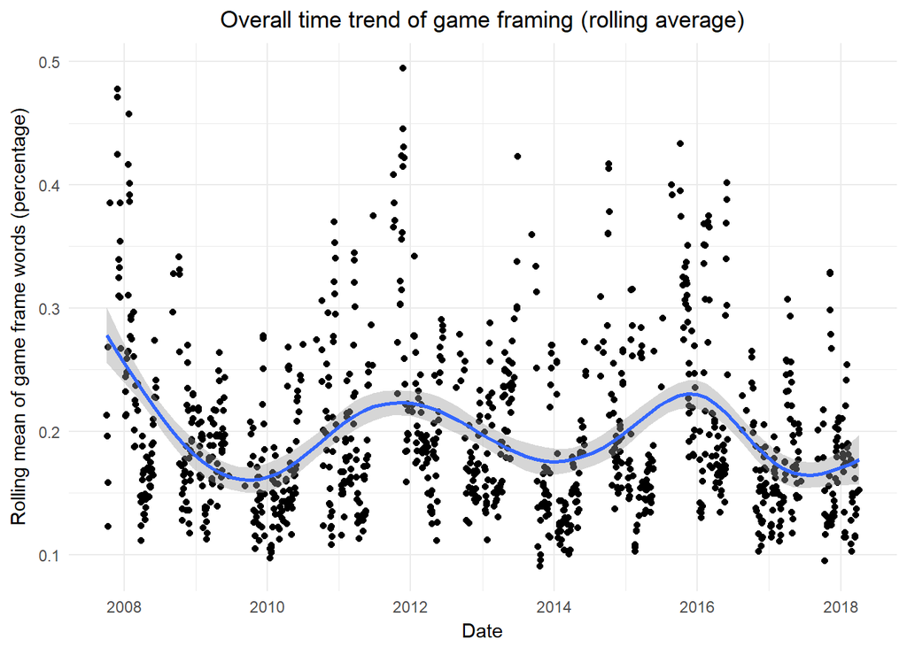

```r
game_frame_data_rolling_mean = game_frame_no_outliers %>%
  mutate(rolling_game_frame_average = rollmean(game_frame_proportion, k = 5, na.pad = TRUE))


overall_trend = ggplot(game_frame_data_rolling_mean, aes(x = date, y = rolling_game_frame_average*100)) +
  geom_point() + # create a plot
  geom_smooth() + # create a smooth line
  theme_minimal() + # set theme
  xlab("Date")+ # set label for x-axis
  ylab("Rolling mean of game frame words (percentage)")+ # set label for y-axis
  theme(plot.title = element_text(hjust = 0.5)) + # center plot title
  ggtitle("Overall time trend of game framing (rolling average)") # plot title

overall_trend
```

It is clear that the presence of game framing undergoes a cyclical trend. I include lines to the plot representing elections dates. Just as expected, the presence of game framing tops simultaneously with the parliamentary elections.

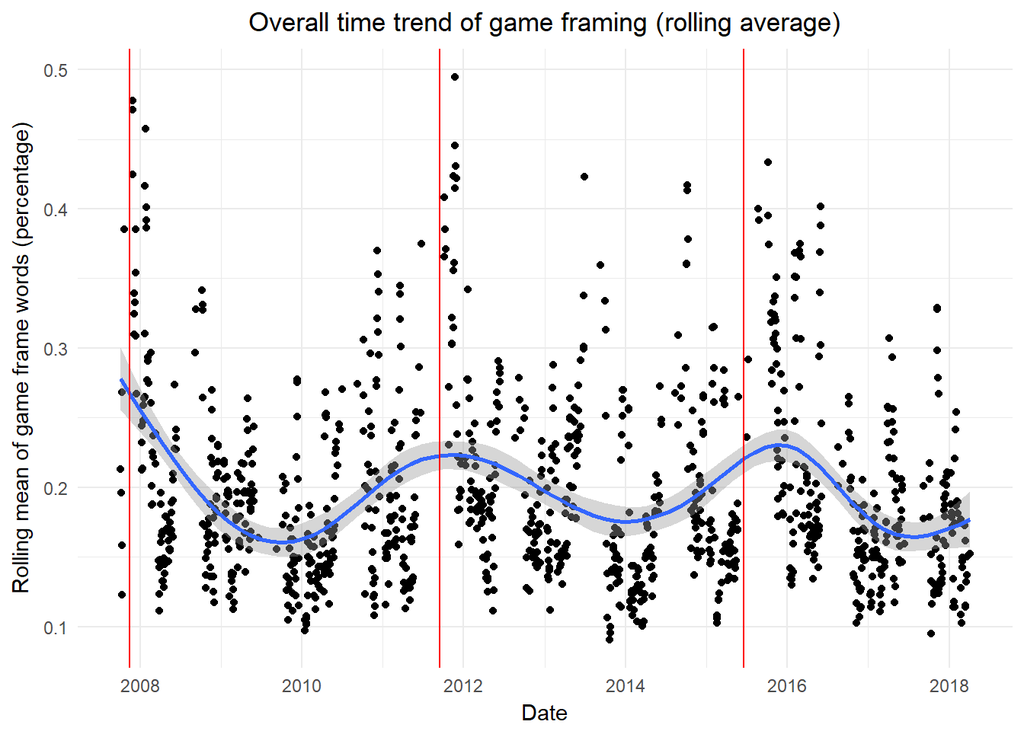

```r
overall_trend = ggplot(game_frame_data_rolling_mean, aes(x = date, y = rolling_game_frame_average*100)) +
  geom_point() + # create a plot
  geom_smooth() + # create a smooth line
  geom_vline(aes(xintercept = as.numeric(election_dates[1])), colour="red") +
  geom_vline(aes(xintercept = as.numeric(election_dates[2])), colour="red") +
  geom_vline(aes(xintercept = as.numeric(election_dates[3])), colour="red") +
  theme_minimal() + # set theme
  xlab("Date")+ # name label for x-axis
  ylab("Rolling mean of game frame words (percentage)")+ # name label for y-axis
  theme(plot.title = element_text(hjust = 0.5)) + # center plot title
  ggtitle("Overall time trend of game framing (rolling average)") # name title

overall_trend
```

```r
# Save the plot
ggsave(filename="cyclical_trend.jpg",
        plot=overall_trend,
        width=18, height=12, units="cm")
```

### Game framing and distance to next election

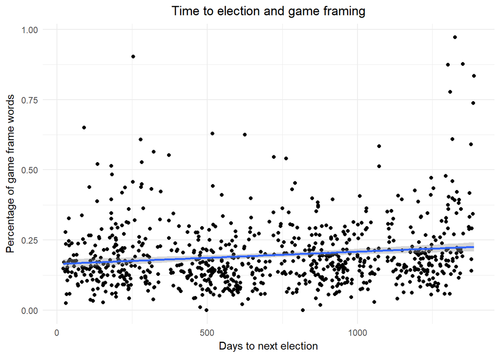

```r
# Association between days to election and presence of game frame

days_to_election_plot = ggplot(game_frame_data_rolling_mean, aes(x = days_to_election, y = game_frame_proportion*100)) +
  geom_point() + # create a plot
  geom_smooth(method='lm', formula = y~x) + # create a smooth line
  theme_minimal() + # set theme
  xlab("Days to next election")+ # name label for x-axis
  ylab("Percentage of game frame words")+ # name label for y-axis
  theme(plot.title = element_text(hjust = 0.5)) + # center plot title
  ggtitle("Time to election and game framing") # name title

days_to_election_plot
```

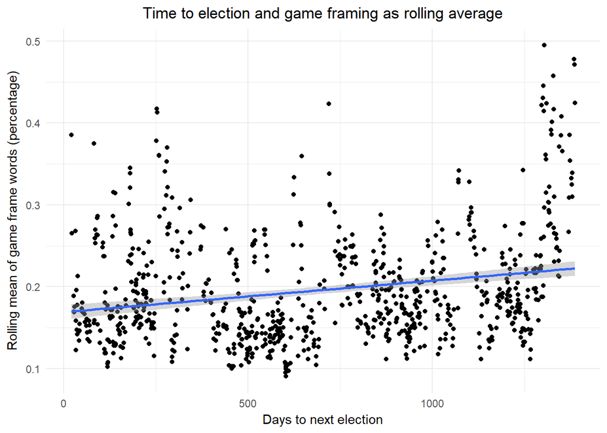

```r
# Association between days to election and presence of game frame as a rolling average

days_to_election_plot = ggplot(game_frame_data_rolling_mean, aes(x = days_to_election, y = rolling_game_frame_average*100)) +
  geom_point() + # create a plot
  geom_smooth(method='lm', formula = y~x) + # create a smooth line
  theme_minimal() + # set theme
  xlab("Days to next election")+ # name label for x-axis
  ylab("Rolling mean of game frame words (percentage)")+ # name label for y-axis
  theme(plot.title = element_text(hjust = 0.5)) + # center plot title
  ggtitle("Time to election and game framing as rolling average") # name title

days_to_election_plot
```

We saw in the visualization of the cyclical trend of the game framing that the presence of game frame words is high both before and after an election. Therefore, it makes sense to measure on *days to closest election* rather than *days to next election*. In the following code section, I create a dataset that contains that exact variable.

```r
### Creating the

# Creating new dataset measuring days to closests election instead of days to next election
closests_election_data = game_frame_data %>%
  mutate(time_to_2015_election = abs(election_dates[1] - game_frame_data$date)) %>% # create a variable that calculates distance in days to 2015 election
  mutate(time_to_2011_election = abs(election_dates[2] - game_frame_data$date)) %>% # create a variable that calculates distance in days to 2011 election
  mutate(time_to_2007_election = abs(election_dates[3] - game_frame_data$date)) # create a variable that calculates distance in days to 2011 election

# For loop returning an vector with the days to closets election
days_to_closets_election_vetor = c() # create an empty vector
for (index in array(1:nrow(closests_election_data))){
  days_to_closets_election_vetor = c(days_to_closets_election_vetor, min(c(closests_election_data$time_to_2015_election[index],
                                                                           closests_election_data$time_to_2011_election[index],
                                                                           closests_election_data$time_to_2007_election[index]), na.rm = TRUE))
}

#Adding a extra variable (days to next election) to the dataset
closests_election_data = closests_election_data %>%
  mutate(days_to_closets_election = days_to_closets_election_vetor) %>% #add the new variable
  mutate(rolling_game_frame_average = rollmean(game_frame_proportion, k = 5, na.pad = TRUE)) # create a variable measuring the rolling average of game frame words
```

If we now plot the days to closest election with the presence of game framing with a linear regression line, we find what we expected: the exact opposite of the previous plot. The closer a parliamentary debate is to the closest election, the more does the politicians use game frame words in the parliamentary debate.

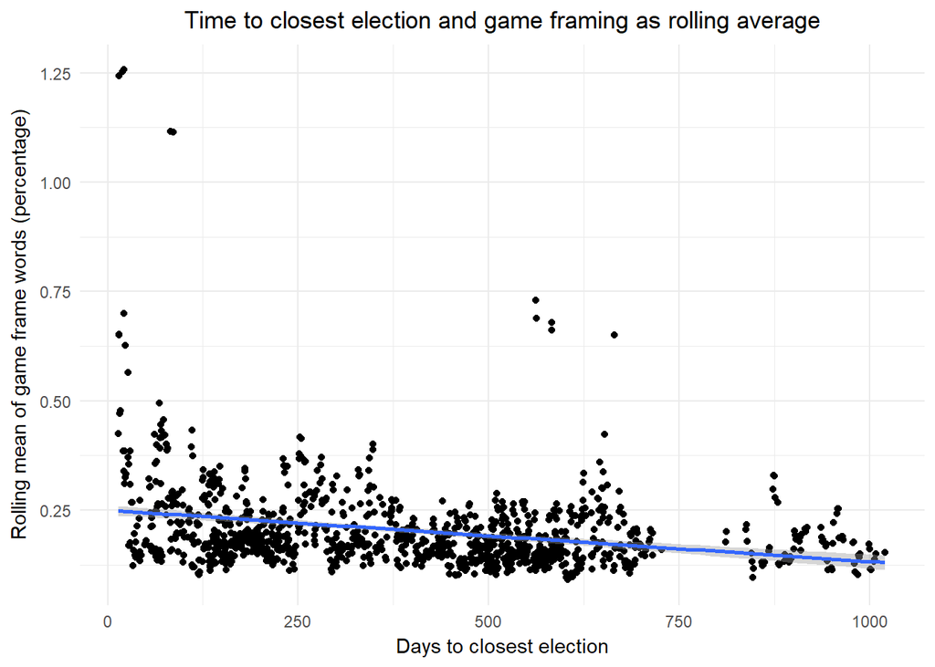

```r
# Association between days to election and presence of game frame as a rolling average

days_to_election_closets_plot = ggplot(closests_election_data, aes(x = days_to_closets_election, y = rolling_game_frame_average*100)) +
  geom_point() + # create a plot
  geom_smooth(method='lm', formula = y~x) + # create a smooth line
  theme_minimal() + # set theme
  xlab("Days to closest election")+ # name label for x-axis
  ylab("Rolling mean of game frame words (percentage)")+ # name label for y-axis
  theme(plot.title = element_text(hjust = 0.5)) + # center plot title
  ggtitle("Time to closest election and game framing as rolling average") # name title

days_to_election_closets_plot
```

```r
# Save the plot
ggsave(filename="time_to_closest_election.jpg",
        plot=days_to_election_closets_plot,
        width=18, height=12, units="cm")
```

Furthermore, we find a statistically significant negative association between days to closest election and rolling average of game frame words in the debate. In other words, the more days there is to an election (both previous or next election) the less frequent do politicians use game frame words in the parliamentary debates. This is statistically significant with a t-value of -9.34.

```r
# Creating the linear model
ln_model = lm(rolling_game_frame_average ~ days_to_closets_election, data=closests_election_data)
```

```r
# Printing the regression table
stargazer(ln_model, type = "html",
          title = "Regression of days to closest election and game framing", #title
          align = TRUE,
          dep.var.labels = c("Rolling average of Game Frame words"), #Y-label
          covariate.labels = c("Number of days to closets election"), #X-label
          out="models.htm") # save as html
```

**Regression of days to closest election and game framing**

|  | *Dependent variable:* |
| --- | --- |
|  | Rolling average of Game Frame words |
| Number of days to closets election | -0.00000*** |
|  | (0.00000) |
| Constant | 0.003*** |
|  | (0.0001) |
| Observations | 1,123 |
| R<sup>2</sup> | 0.072 |
| Adjusted R<sup>2</sup> | 0.071 |
| Residual Std. Error | 0.001 (df = 1121) |
| F Statistic | 87.228*** (df = 1; 1121) |
| *Note:* | p<0.1; p<0.05; p<0.01 |